# Lab 6 - Model selection

Ilaria Prosdocimi

26 October 2021

We will analyze the dataset `prostate`:

```r
urlLocation <- "https://web.stanford.edu/~hastie/ElemStatLearn/datasets/prostate.data"
prostate <- read.table(urlLocation, header=TRUE)[,1:9]
## explanation of the data
## https://web.stanford.edu/~hastie/ElemStatLearn/datasets/prostate.info.txt
## save the data locally as
## write.csv(x = prostate, file = "prostate.csv", row.names = FALSE, quote = FALSE)
## so you can re-read as
## prostate <- read.csv("prostate.csv", header = TRUE)
```

The variables in the dataset are

- lcavol: log cancer volume
- lweight: log prostate weight
- age: age of patient
- lbph: log of the amount of benign prostatic hyperplasia
- svi: seminal vesicle invasion (binary variable)
- lcp: log of capsular penetration
- gleason: Gleason score
- pgg45: percent of Gleason scores 4 or 5
- lpsa: log PSA score

We aim to select a model that to explain how `lpsa` is affected by other variables: this might be useful both for prediction purposes (i.e. predict the `lpsa` for a new patient) and for inference purposes (i.e. understanding which factors influence the `lpsa` values).

The relationship of `lpsa` against all the other variables in the dataset can be seen in the plot below:

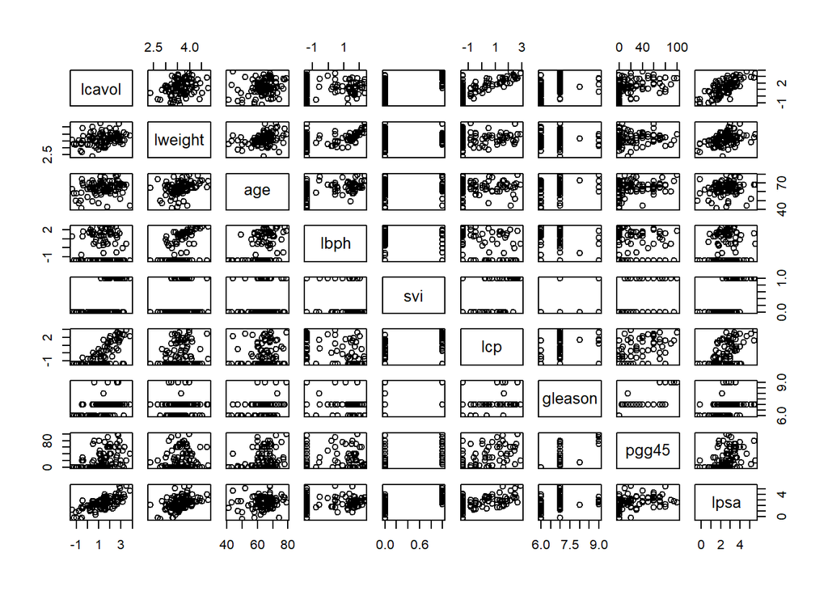

```r
plot(prostate)
```

```r
fit_minimum <- lm(lpsa ~ 1, data = prostate)
fit_maximum <- lm(lpsa ~ ., data = prostate)
```

```r
AIC(fit_minimum)
```

```
## [1] 306.1116
```

```r
AIC(fit_maximum)
```

```
## [1] 216.4952
```

```r
for(j in 1:8){
  print(c(names(prostate)[j],AIC(lm(prostate$lpsa~prostate[,j]))))
}
```

```
## [1] "lcavol"           "232.908040520779"
## [1] "lweight"          "287.938884382005"
## [1] "age"             "305.28083171633"
## [1] "lbph"             "304.923660989906"
## [1] "svi"              "270.616301177566"
## [1] "lcp"              "273.348297964505"
## [1] "gleason"          "293.914939851134"
## [1] "pgg45"            "289.056791954584"
```

```r
fit_for1 <- lm(lpsa ~ lcavol, data = prostate)
## end of step 1
```

```r
AIC(fit_for1)
```

```
## [1] 232.908
```

```r
for(j in 2:8){
  print(c(names(prostate)[j],
          AIC(lm(prostate$lpsa~prostate$lcavol + prostate[,j]))))
}
```

```
## [1] "lweight"          "222.315614002795"
## [1] "age"              "234.903863181463"
## [1] "lbph"             "229.376352455054"
## [1] "svi"              "225.877148514224"
## [1] "lcp"              "233.821580621122"
## [1] "gleason"          "234.221392721187"
## [1] "pgg45"            "232.071362615846"
```

```r
fit_for2 <- lm(lpsa ~ lcavol+lweight, data = prostate)
## end of step 2
```

```r
AIC(fit_for2)
```

```
## [1] 222.3156
```

```r
for(j in 3:8){
  print(c(names(prostate)[j],
          AIC(lm(prostate$lpsa~prostate$lcavol +
                               prostate$lweight +
                               prostate[,j]))))
}
```

```
## [1] "age"              "223.097628381145"
## [1] "lbph"             "223.479590896848"
## [1] "svi"              "214.096639677601"
## [1] "lcp"              "222.768510378058"
## [1] "gleason"          "222.963396667275"
## [1] "pgg45"            "220.850454810872"
```

```r
fit_for3 <- lm(lpsa ~ lcavol+lweight+svi, data = prostate)
## end of step 3
```

```r
AIC(fit_for3)
```

```
## [1] 214.0966
```

```r
for(j in c(3,4,6,7,8)){
  print(c(names(prostate)[j],
          AIC(lm(prostate$lpsa~prostate$lcavol +
                               prostate$lweight +
                               prostate$svi +
                               prostate[,j]))))
}
```

```
## [1] "age"              "214.790180691189"
## [1] "lbph"             "214.048526941322"
## [1] "lcp"             "215.95203193088"
## [1] "gleason"          "215.376419356565"
## [1] "pgg45"            "215.048086136489"
```

```r
fit_for4 <- lm(lpsa ~ lcavol+lweight+svi+lbph, data = prostate)
## end of step 4
```

```r
AIC(fit_for4)
```

```
## [1] 214.0485
```

```r
for(j in c(3,6,7,8)){
  print(c(names(prostate)[j],
          AIC(lm(prostate$lpsa~prostate$lcavol +
                               prostate$lweight +
                               prostate$svi +
                               prostate$lbph +
                               prostate[,j]))))
}
```

```
## [1] "age"              "213.551444113236"
## [1] "lcp"              "215.833092389948"
## [1] "gleason"          "215.607345779962"
## [1] "pgg45"            "215.340212753446"
```

```r
fit_for5 <- lm(lpsa ~ lcavol+lweight+svi+lbph+age, data = prostate)
## end of step 5
```

```r
AIC(fit_for5)
```

```
## [1] 213.5514
```

```r
for(j in c(6,7,8)){
  print(c(names(prostate)[j],
          AIC(lm(prostate$lpsa~prostate$lcavol +
                               prostate$lweight +
                               prostate$svi +
                               prostate$lbph +
                               prostate$age +
                               prostate[,j]))))
}
```

```
## [1] "lcp"              "215.266377832168"
## [1] "gleason"          "214.505152307028"
## [1] "pgg45"            "214.098367914233"
```

```r
## end of step 6
```

```r
step(object = fit_minimum,
     scope = list(upper = fit_maximum,
                  lower = fit_minimum),
     direction = "forward",
     # usiamo AIC
     k = 2)
```

```
## Start:  AIC=28.84
## lpsa ~ 1
##
##           Df Sum of Sq     RSS     AIC
## + lcavol   1    69.003  58.915 -44.366
## + svi      1    41.011  86.907  -6.658
## + lcp      1    38.528  89.389  -3.926
## + lweight  1    24.019 103.899  10.665
## + pgg45    1    22.814 105.103  11.783
## + gleason  1    17.416 110.502  16.641
## + lbph     1     4.136 123.782  27.650
## + age      1     3.679 124.239  28.007
## <none>                 127.918  28.838
##
## Step:  AIC=-44.37
## lpsa ~ lcavol
##
##           Df Sum of Sq    RSS     AIC
## + lweight  1    7.1726 51.742 -54.958
## + svi      1    5.2375 53.677 -51.397
## + lbph     1    3.2658 55.649 -47.898
## + pgg45    1    1.6980 57.217 -45.203
## <none>                 58.915 -44.366
## + lcp      1    0.6562 58.259 -43.452
## + gleason  1    0.4156 58.499 -43.053
## + age      1    0.0025 58.912 -42.370
##
## Step:  AIC=-54.96
## lpsa ~ lcavol + lweight
##
##           Df Sum of Sq    RSS     AIC
## + svi      1    5.1737 46.568 -63.177
## + pgg45    1    1.8158 49.926 -56.424
## <none>                 51.742 -54.958
## + lcp      1    0.8187 50.923 -54.506
## + gleason  1    0.7163 51.026 -54.311
## + age      1    0.6456 51.097 -54.176
## + lbph     1    0.4440 51.298 -53.794
##
## Step:  AIC=-63.18
```

[output cut: 13 more lines]

```
##           Df Sum of Sq    RSS     AIC
## + age      1   1.15879 44.437 -63.723
## <none>                 45.595 -63.226
## + pgg45    1   0.33173 45.264 -61.934
## + gleason  1   0.20691 45.389 -61.667
## + lcp      1   0.10115 45.494 -61.441
##
## Step:  AIC=-63.72
## lpsa ~ lcavol + lweight + svi + lbph + age
##
##           Df Sum of Sq    RSS     AIC
## <none>                 44.437 -63.723
## + pgg45    1   0.66071 43.776 -63.176
## + gleason  1   0.47674 43.960 -62.769
## + lcp      1   0.13040 44.306 -62.008
```

```
##
## Call:
## lm(formula = lpsa ~ lcavol + lweight + svi + lbph + age, data = prostate)
##
## Coefficients:
## (Intercept)       lcavol      lweight          svi         lbph          age
##     0.49473      0.54400      0.58821      0.71490      0.10122     -0.01644
```

```r
aic_bsel <-
  step(object = fit_maximum,
     scope = list(upper = fit_maximum,
                  lower = fit_minimum),
     direction = "backward",
     # usiamo AIC
     k = 2)
```

```
## Start:  AIC=-60.78
## lpsa ~ lcavol + lweight + age + lbph + svi + lcp + gleason +
##     pgg45
##
##           Df Sum of Sq    RSS     AIC
## - gleason  1    0.0491 43.108 -62.668
## - pgg45    1    0.5102 43.569 -61.636
## - lcp      1    0.6814 43.740 -61.256
## <none>                 43.058 -60.779
## - lbph     1    1.3646 44.423 -59.753
## - age      1    1.7981 44.857 -58.810
## - lweight  1    4.6907 47.749 -52.749
## - svi      1    4.8803 47.939 -52.364
## - lcavol   1   20.1994 63.258 -25.467
##
## Step:  AIC=-62.67
## lpsa ~ lcavol + lweight + age + lbph + svi + lcp + pgg45
##
##           Df Sum of Sq    RSS     AIC
## - lcp      1    0.6684 43.776 -63.176
## <none>                 43.108 -62.668
## - pgg45    1    1.1987 44.306 -62.008
## - lbph     1    1.3844 44.492 -61.602
## - age      1    1.7579 44.865 -60.791
## - lweight  1    4.6429 47.751 -54.746
## - svi      1    4.8333 47.941 -54.360
## - lcavol   1   21.3191 64.427 -25.691
##
## Step:  AIC=-63.18
## lpsa ~ lcavol + lweight + age + lbph + svi + pgg45
##
##           Df Sum of Sq    RSS     AIC
## - pgg45    1    0.6607 44.437 -63.723
## <none>                 43.776 -63.176
## - lbph     1    1.3329 45.109 -62.266
## - age      1    1.4878 45.264 -61.934
## - svi      1    4.1766 47.953 -56.336
## - lweight  1    4.6553 48.431 -55.373
## - lcavol   1   22.7555 66.531 -24.572
##
## Step:  AIC=-63.72
## lpsa ~ lcavol + lweight + age + lbph + svi
##
##           Df Sum of Sq    RSS     AIC
## <none>                 44.437 -63.723
## - age      1    1.1588 45.595 -63.226
## - lbph     1    1.5087 45.945 -62.484
## - lweight  1    4.3140 48.751 -56.735
## - svi      1    5.8509 50.288 -53.724
## - lcavol   1   25.9427 70.379 -21.119
```

Cosa succede se usiamo il BIC come criterio di scelta? Il BIC si differenzia dall’AIC per l’uso di log(n) invece che 2 per penalizzare la complessità del modello.

```r
step(object = fit_minimum,
     scope = list(upper = fit_maximum,
                  lower = fit_minimum),
     direction = "forward",
     # usiamo BIC
     k = log(nrow(prostate)))
```

```
## Start:  AIC=31.41
## lpsa ~ 1
##
##           Df Sum of Sq     RSS     AIC
## + lcavol   1    69.003  58.915 -39.217
## + svi      1    41.011  86.907  -1.508
## + lcp      1    38.528  89.389   1.224
## + lweight  1    24.019 103.899  15.814
## + pgg45    1    22.814 105.103  16.932
## + gleason  1    17.416 110.502  21.790
## <none>                 127.918  31.412
## + lbph     1     4.136 123.782  32.799
## + age      1     3.679 124.239  33.156
##
## Step:  AIC=-39.22
## lpsa ~ lcavol
##
##           Df Sum of Sq    RSS     AIC
## + lweight  1    7.1726 51.742 -47.234
## + svi      1    5.2375 53.677 -43.673
## + lbph     1    3.2658 55.649 -40.174
## <none>                 58.915 -39.217
## + pgg45    1    1.6980 57.217 -37.479
## + lcp      1    0.6562 58.259 -35.728
## + gleason  1    0.4156 58.499 -35.329
## + age      1    0.0025 58.912 -34.646
##
## Step:  AIC=-47.23
## lpsa ~ lcavol + lweight
##
##           Df Sum of Sq    RSS     AIC
## + svi      1    5.1737 46.568 -52.879
## <none>                 51.742 -47.234
## + pgg45    1    1.8158 49.926 -46.125
## + lcp      1    0.8187 50.923 -44.207
## + gleason  1    0.7163 51.026 -44.012
## + age      1    0.6456 51.097 -43.878
## + lbph     1    0.4440 51.298 -43.496
##
## Step:  AIC=-52.88
## lpsa ~ lcavol + lweight + svi
##
##           Df Sum of Sq    RSS     AIC
## <none>                 46.568 -52.879
## + lbph     1   0.97296 45.595 -50.352
## + age      1   0.62301 45.945 -49.610
## + pgg45    1   0.50069 46.068 -49.352
## + gleason  1   0.34449 46.224 -49.024
## + lcp      1   0.06937 46.499 -48.448
```

```
##
## Call:
## lm(formula = lpsa ~ lcavol + lweight + svi, data = prostate)
##
## Coefficients:
## (Intercept)       lcavol      lweight          svi
##     -0.7772       0.5259       0.6618       0.6657
```

```r
bic_bsel <-
  step(object = fit_maximum,
     scope = list(upper = fit_maximum,
                  lower = fit_minimum),
     direction = "backward",
     # usiamo BIC
     k = log(nrow(prostate)),
     trace = 0)
```

```r
step(object = lm(lpsa ~ lcavol, data = prostate),
     scope = list(upper = fit_maximum,
                  lower = fit_minimum),
     direction = "both",
     # usiamo BIC
     k = log(nrow(prostate)))
```

```
## Start:  AIC=-39.22
## lpsa ~ lcavol
##
##           Df Sum of Sq     RSS     AIC
## + lweight  1     7.173  51.742 -47.234
## + svi      1     5.237  53.677 -43.673
## + lbph     1     3.266  55.649 -40.174
## <none>                  58.915 -39.217
## + pgg45    1     1.698  57.217 -37.479
## + lcp      1     0.656  58.259 -35.728
## + gleason  1     0.416  58.499 -35.329
## + age      1     0.003  58.912 -34.646
## - lcavol   1    69.003 127.918  31.412
##
## Step:  AIC=-47.23
## lpsa ~ lcavol + lweight
##
##           Df Sum of Sq     RSS     AIC
## + svi      1     5.174  46.568 -52.879
## <none>                  51.742 -47.234
## + pgg45    1     1.816  49.926 -46.125
## + lcp      1     0.819  50.923 -44.207
## + gleason  1     0.716  51.026 -44.012
## + age      1     0.646  51.097 -43.878
## + lbph     1     0.444  51.298 -43.496
## - lweight  1     7.173  58.915 -39.217
## - lcavol   1    52.157 103.899  15.814
##
## Step:  AIC=-52.88
## lpsa ~ lcavol + lweight + svi
##
##           Df Sum of Sq    RSS     AIC
## <none>                 46.568 -52.879
## + lbph     1    0.9730 45.595 -50.352
## + age      1    0.6230 45.945 -49.610
## + pgg45    1    0.5007 46.068 -49.352
## + gleason  1    0.3445 46.224 -49.024
## + lcp      1    0.0694 46.499 -48.448
## - svi      1    5.1737 51.742 -47.234
## - lweight  1    7.1089 53.677 -43.673
## - lcavol   1   24.7058 71.274 -16.169
```

```
##
## Call:
## lm(formula = lpsa ~ lcavol + lweight + svi, data = prostate)
##
## Coefficients:
## (Intercept)       lcavol      lweight          svi
##     -0.7772       0.5259       0.6618       0.6657
```

## Exhaustive search

```r
# install.packages("leaps")
library(leaps)
```

```r
rg_1 <- regsubsets(lpsa~., data = prostate)
summary(rg_1)
```

```
## Subset selection object
## Call: regsubsets.formula(lpsa ~ ., data = prostate)
## 8 Variables  (and intercept)
##         Forced in Forced out
## lcavol      FALSE      FALSE
## lweight     FALSE      FALSE
## age         FALSE      FALSE
## lbph        FALSE      FALSE
## svi         FALSE      FALSE
## lcp         FALSE      FALSE
## gleason     FALSE      FALSE
## pgg45       FALSE      FALSE
## 1 subsets of each size up to 8
## Selection Algorithm: exhaustive
##          lcavol lweight age lbph svi lcp gleason pgg45
## 1  ( 1 ) "*"    " "     " " " "  " " " " " "     " "
## 2  ( 1 ) "*"    "*"     " " " "  " " " " " "     " "
## 3  ( 1 ) "*"    "*"     " " " "  "*" " " " "     " "
## 4  ( 1 ) "*"    "*"     " " "*"  "*" " " " "     " "
## 5  ( 1 ) "*"    "*"     "*" "*"  "*" " " " "     " "
## 6  ( 1 ) "*"    "*"     "*" "*"  "*" " " " "     "*"
## 7  ( 1 ) "*"    "*"     "*" "*"  "*" "*" " "     "*"
## 8  ( 1 ) "*"    "*"     "*" "*"  "*" "*" "*"     "*"
```

```r
summary(rg_1)$rsq
```

```
## [1] 0.5394320 0.5955040 0.6359499 0.6435561 0.6526150 0.6577801 0.6630054
## [8] 0.6633896
```

```r
summary(rg_1)$adjr2
```

```
## [1] 0.5345839 0.5868977 0.6242063 0.6280585 0.6335279 0.6349654 0.6365002
## [8] 0.6327886
```

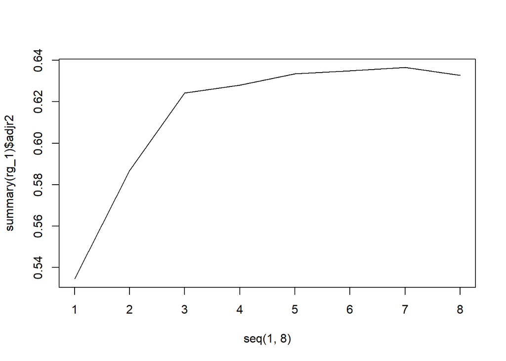

```r
plot(seq(1, 8), summary(rg_1)$adjr2, type = "l")
```

```r
summary(rg_1)$which
```

```
##   (Intercept) lcavol lweight   age  lbph   svi   lcp gleason pgg45
## 1        TRUE   TRUE   FALSE FALSE FALSE FALSE FALSE   FALSE FALSE
## 2        TRUE   TRUE    TRUE FALSE FALSE FALSE FALSE   FALSE FALSE
## 3        TRUE   TRUE    TRUE FALSE FALSE  TRUE FALSE   FALSE FALSE
## 4        TRUE   TRUE    TRUE FALSE  TRUE  TRUE FALSE   FALSE FALSE
## 5        TRUE   TRUE    TRUE  TRUE  TRUE  TRUE FALSE   FALSE FALSE
## 6        TRUE   TRUE    TRUE  TRUE  TRUE  TRUE FALSE   FALSE  TRUE
## 7        TRUE   TRUE    TRUE  TRUE  TRUE  TRUE  TRUE   FALSE  TRUE
## 8        TRUE   TRUE    TRUE  TRUE  TRUE  TRUE  TRUE    TRUE  TRUE
```

## Validazione incrociata (leave one out cross validation)

```r
loo_cv_vals <- NULL  # e_[i]
for(i in 1:nrow(prostate)){
  refit <- lm(formula = lpsa ~ lcavol + lweight + svi,
              data = prostate[-i,])
  loo_cv_vals <- c(loo_cv_vals,
                   (prostate[i,"lpsa"] -
                     predict(refit, newdata = prostate[i,])))
}
length(loo_cv_vals)
```

```
## [1] 97
```

```r
sum(loo_cv_vals^2)/nrow(prostate)
```

```
## [1] 0.5255275
```

```r
## now for the model selected by AIC
loo_cv_vals <- NULL  # e_[i]
for(i in 1:nrow(prostate)){
  refit <- lm(formula = lpsa ~ lcavol + lweight + age + lbph + svi,
              data = prostate[-i,])
  loo_cv_vals <- c(loo_cv_vals,
                   (prostate[i,"lpsa"] -
                     predict(refit, newdata = prostate[i,])))
}
length(loo_cv_vals)
```

```
## [1] 97
```

```r
sum(loo_cv_vals^2)/nrow(prostate)
```

```
## [1] 0.5256991
```

```r
X <- model.matrix(bic_bsel)
Hmat <- X %*% solve(t(X) %*% X) %*% t(X)
yhat <- Hmat %*% prostate$lpsa
sum((residuals(bic_bsel)/(1-diag(Hmat)))^2)/nrow(prostate)
```

```
## [1] 0.5255275
```

```r
calc_loo_rmse <- function(model){
  sqrt(mean((residuals(model)/(1-hatvalues(model)))^2))
}
calc_loo_rmse(bic_bsel)
```

```
## [1] 0.7249328
```

# Verificare le assunzioni del modello

Omoschdasticità

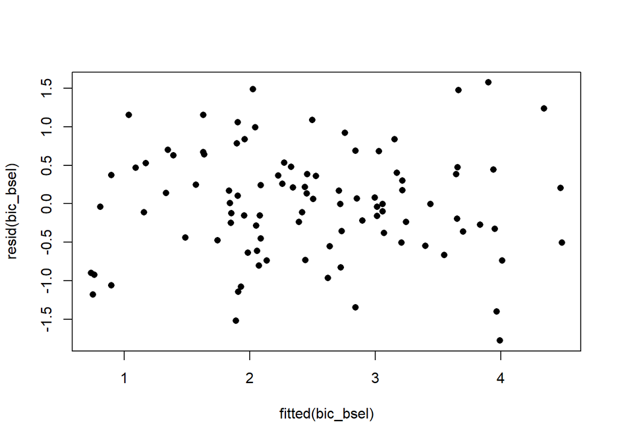

```r
plot(fitted(bic_bsel), resid(bic_bsel), pch = 16)
```

Va bene se… non c’è relazione evidente e la varianza è costante. Sembra OK.

Normalità

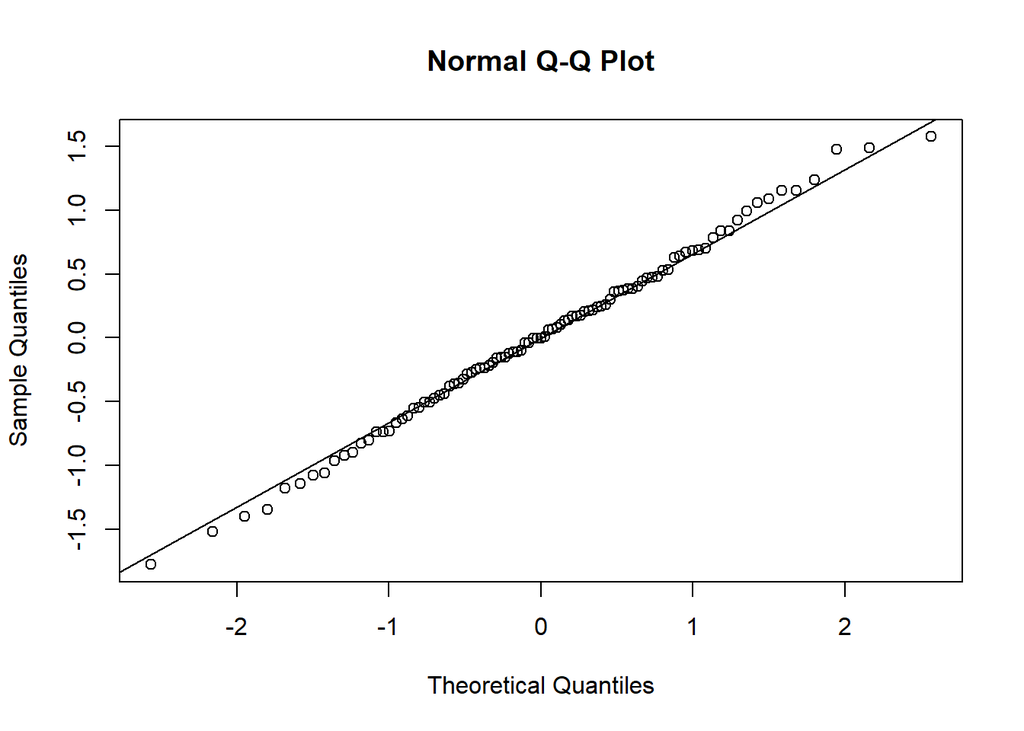

```r
qqnorm(resid(bic_bsel)); qqline(resid(bic_bsel))
```

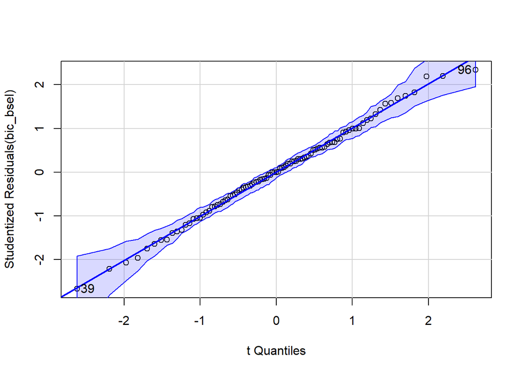

```
## [1] 39 96
```

```r
car::qqPlot(bic_bsel)
```